# Reporte de ejercicios de Introducción a R

- Mostrar todo el código
- Ocultar todo el código
- Ver el código fuente

Bioinformática I | Temas 3 a 10

Autor/a

Alonso García Ramírez

Fecha de publicación

26 de noviembre de 2026

# Introducción

En este reporte reúno las actividades prácticas del curso Introducción a R para Bioinformática I, desde los objetos de R hasta la visualización de datos. El objetivo es practicar el manejo de secuencias, conteos, metadatos y tablas taxonómicas, y documentar los resultados para poder repetir el análisis.

# Datos y metodología

Utilicé los archivos del curso: datos sintéticos de BLAST, expresión génica simulada de 40 genes en seis muestras y datos de rizosfera. Los archivos originales se conservan en `data_raw/`, los resultados procesados se guardan en `results/` y las figuras en `figures/`. El código usa rutas relativas y se ejecuta desde la raíz del proyecto.

# Resultados de los ejercicios

## 3. Objetos y estructuras de datos

### 3.2.1 — Ejercicio 1: vectores y selección

Selecciono un gen por posición y después filtro los genes de longitud igual o mayor a 300 pb.

**Código**

```r
ids <- c("g1", "g2", "g3", "g4", "g5")
tam <- c(90, 450, 310, 120, 600)
ids[3]
```

```
[1] "g3"
```

**Código**

```r
ids[tam >= 300]
```

```
[1] "g2" "g3" "g5"
```

**Código**

```r
sum(tam >= 300)
```

```
[1] 3
```

El tercero es g3 y hay tres genes que cumplen la condición: g2, g3 y g5.

### 3.2.4 — Ejercicio 2: factores

**Código**

```r
letras <- c("A", "M", "A", "B", "M", "M", "B", "A", "B", "B")
nivel <- factor(letras, levels = c("B", "M", "A"), ordered = TRUE)
nivel
```

```
 [1] A M A B M M B A B B
Levels: B < M < A
```

**Código**

```r
levels(nivel)
```

```
[1] "B" "M" "A"
```

El orden va de bajo a alto, por lo que A es mayor que M y M es mayor que B.

### 3.2.5 — Ejercicio 3: estructuras

**Código**

```r
genes <- data.frame(gen = c("g1", "g2", "g3"),
                    longitud = c(450, 120, 800),
                    funcion = c("Enzima", "Transportador", "Hipotética"))
genes[genes$longitud > 200, ]
```

```
  gen longitud    funcion
1  g1      450     Enzima
3  g3      800 Hipotética
```

**Código**

```r
muestra <- list(id = "M01", anotaciones = genes)
muestra
```

```
$id
[1] "M01"

$anotaciones
  gen longitud       funcion
1  g1      450        Enzima
2  g2      120 Transportador
3  g3      800    Hipotética
```

Un data frame permite conservar las longitudes como números y las etiquetas como texto. Una matriz de caracteres convertiría también las longitudes a texto.

## 4. Estructuras de control

### 4.1.1 — Ejercicio 1: clasificar conteos

**Código**

```r
for (conteo in c(NA, -2, 0, 15)) {
  if (is.na(conteo)) {
    print("Dato faltante")
  } else if (conteo < 0) {
    print("Conteo inválido")
  } else if (conteo == 0) {
    print("Sin lecturas")
  } else {
    print("Con lecturas")
  }
}
```

```
[1] "Dato faltante"
[1] "Conteo inválido"
[1] "Sin lecturas"
[1] "Con lecturas"
```

Primero revisé si el dato es faltante, porque comparar directamente un NA con un número puede producir errores.

### 4.1.2 — Ejercicio 2: comprobar conteos

**Código**

```r
conteos <- c(8, 0, 13, 5, 0, 21)
all(conteos >= 0)
```

```
[1] TRUE
```

**Código**

```r
any(conteos > 20)
```

```
[1] TRUE
```

**Código**

```r
which(conteos == 0)
```

```
[1] 2 5
```

**Código**

```r
ifelse(conteos > 0, "Presente", "Ausente")
```

```
[1] "Presente" "Ausente"  "Presente" "Presente" "Ausente"  "Presente"
```

Todos son no negativos; sí hay uno mayor que 20 y los ceros están en las posiciones 2 y 5.

### 4.2.2 — Ejercicio 3: longitudes de secuencias

**Código**

```r
secuencias <- c("ATG", "ATGCGT", "AATTCCGG", "CG")
longitudes <- numeric(length(secuencias))
clasificacion <- character(length(secuencias))
for (i in seq_along(secuencias)) {
  longitudes[i] <- nchar(secuencias[i])
  if (longitudes[i] < 5) {
    clasificacion[i] <- "Corta"
  } else {
    clasificacion[i] <- "Larga"
  }
}
longitudes
```

```
[1] 3 6 8 2
```

**Código**

```r
clasificacion
```

```
[1] "Corta" "Larga" "Larga" "Corta"
```

Las secuencias de 3 y 2 bases son cortas y las de 6 y 8 son largas.

### 4.3.2 — Ejercicio 4: longitud con while

**Código**

```r
secuencia <- ""
while (nchar(secuencia) < 8) {
  secuencia <- paste0(secuencia, "A")
}
secuencia
```

```
[1] "AAAAAAAA"
```

El ciclo termina cuando se obtienen ocho adeninas.

## 5. Funciones en R

### 5.1 — Ejercicio 1: reconocer un prefijo

**Código**

```r
empieza_con <- function(secuencia, prefijo) {
  substr(secuencia, 1, nchar(prefijo)) == prefijo
}
empieza_con("ATGCGT", "ATG")
```

```
[1] TRUE
```

**Código**

```r
empieza_con("ATGCGT", "TGA")
```

```
[1] FALSE
```

La primera comparación es verdadera y la segunda falsa.

### 5.3 — Ejercicio 2: proporción GC

**Código**

```r
resumir_adn <- function(id, secuencia) {
  secuencia <- toupper(secuencia)
  bases <- strsplit(secuencia, "", fixed = TRUE)[[1]]
  longitud <- nchar(secuencia)
  conteo_gc <- sum(bases %in% c("G", "C"))
  list(id = id, longitud = longitud, conteo_gc = conteo_gc,
       proporcion_gc = ifelse(longitud > 0, conteo_gc / longitud, NA_real_))
}
resumir_adn("GEN_01", "ATGCGTAA")
```

```
$id
[1] "GEN_01"

$longitud
[1] 8

$conteo_gc
[1] 3

$proporcion_gc
[1] 0.375
```

La secuencia tiene 8 bases, 3 G o C y una proporción GC de 0.375 (37.5 %).

### 5.5 — Ejercicio 3: secuencias válidas e inválidas

**Código**

```r
revisar_secuencias <- function(secuencias) {
  resultado <- logical(length(secuencias))
  for (i in seq_along(secuencias)) {
    s <- secuencias[i]
    if (!is.na(s)) {
      resultado[i] <- grepl("^[ACGT]+$", toupper(s))
    }
  }
  resultado
}

clasificar_secuencias <- function(secuencias) {
  stopifnot(is.character(secuencias))
  validas <- revisar_secuencias(secuencias)
  list(validas = secuencias[validas], invalidas = secuencias[!validas])
}
clasificar_secuencias(c("ATGCGT", "ACNTGA", "ttacga", NA))
```

```
$validas
[1] "ATGCGT" "ttacga"

$invalidas
[1] "ACNTGA" NA
```

Se aceptan las letras A, C, G y T, incluso en minúsculas. Una N o un dato faltante son inválidos para este criterio.

### 5.6 — Ejercicio 4: reporte de secuencias

**Código**

```r
crear_reporte_secuencias <- function(ids, secuencias) {
  stopifnot(is.character(ids), is.character(secuencias),
            length(ids) == length(secuencias))
  valida <- revisar_secuencias(secuencias)
  longitud <- nchar(secuencias)
  longitud[!valida] <- NA_integer_
  data.frame(id = ids, secuencia = secuencias,
             longitud = longitud, valida = valida)
}
ids <- c("seq_01", "seq_02", "seq_03", "seq_04")
secuencias <- c("ATGCGT", "ACNTGA", "GGCCAA", "TTTAAA")
knitr::kable(crear_reporte_secuencias(ids, secuencias))
```

| id | secuencia | longitud | valida |
| --- | --- | --- | --- |
| seq_01 | ATGCGT | 6 | TRUE |
| seq_02 | ACNTGA | NA | FALSE |
| seq_03 | GGCCAA | 6 | TRUE |
| seq_04 | TTTAAA | 6 | TRUE |

La segunda secuencia tiene una base N, por eso recibe NA en su longitud.

## 6. Scripts, paquetes y proyectos

### Ejercicio 1: script independiente

El script original podría fallar porque usa objetos que no define. Para que sea reproducible, estos deben crearse antes de calcular las longitudes. Guardé el siguiente código como `scripts/revision.R`.

**Código**

```r
ids <- c("seq_01", "seq_02", "seq_03")
secuencias <- c("ATGCGT", "ACGT", "GGCCAA")
longitudes <- nchar(secuencias)
resultado <- data.frame(id = ids, longitud = longitudes)
print(resultado)
```

```
      id longitud
1 seq_01        6
2 seq_02        4
3 seq_03        6
```

Así se puede ejecutar desde una sesión limpia de R.

## 7. Importación y exploración de datos

### Ejercicio 1: reconocer el separador

**Código**

```r
carpeta <- "data_raw/datos_sesion_02_blast"
archivo <- file.path(carpeta, "blast_separador_incorrecto.csv")
file.exists(archivo)
```

```
[1] TRUE
```

**Código**

```r
lineas <- readLines(archivo, n = 3)
lineas
```

```
[1] "query_id\tsubject_id\tpident\tlength\tevalue\tbitscore"
[2] "seq01\tref_001\t87.9\t216\t1.00e-40\t118.7"
[3] "seq01\tref_002\t68.2\t245\t1.00e-36\t184.6"
```

**Código**

```r
grepl("\t", lineas)
```

```
[1] TRUE TRUE TRUE
```

Aunque termina en .csv, contiene tabulaciones y no comas.

### Ejercicio 2: lectura con readr

**Código**

```r
metadata <- read_csv(file.path(carpeta, "metadata_secuencias.csv"),
                     col_types = cols(codigo_muestra = col_character()))
comentarios <- read_tsv(file.path(carpeta, "blast_comentarios.tsv"),
                        comment = "#", show_col_types = FALSE)
class(metadata)
```

```
[1] "spec_tbl_df" "tbl_df"      "tbl"         "data.frame"
```

**Código**

```r
class(comentarios)
```

```
[1] "spec_tbl_df" "tbl_df"      "tbl"         "data.frame"
```

**Código**

```r
head(metadata)
```

```
# A tibble: 6 × 4
  query_id organismo  origen codigo_muestra
  <chr>    <chr>      <chr>  <chr>
1 seq01    Bacteria_A suelo  001
2 seq02    Bacteria_B agua   002
3 seq03    Bacteria_C suelo  003
4 seq04    Bacteria_A agua   004
5 seq05    Bacteria_B suelo  005
6 seq06    Bacteria_C agua   006
```

**Código**

```r
head(comentarios)
```

```
# A tibble: 6 × 6
  query_id subject_id pident length evalue bitscore
  <chr>    <chr>       <dbl>  <dbl>  <dbl>    <dbl>
1 seq01    ref_001      87.9    216  1e-40     119.
2 seq01    ref_002      68.2    245  1e-36     185.
3 seq01    ref_003      93.5    168  1e-35     386.
4 seq02    ref_004      82.6    111  1e-85     260.
5 seq02    ref_005      68.7    292  1e-57     323.
6 seq03    ref_007      88.2    254  1e- 5     362.
```

Los códigos como 001 se mantienen como texto para no perder los ceros. El argumento comment permite omitir los comentarios.

### Ejercicio 3: explorar resultados BLAST

**Código**

```r
blast <- read_tsv(file.path(carpeta, "resultados_blast.tsv"), show_col_types = FALSE)
dim(blast)
```

```
[1] 20  6
```

**Código**

```r
length(unique(blast$query_id))
```

```
[1] 8
```

**Código**

```r
table(blast$query_id)
```

```
seq01 seq02 seq03 seq04 seq05 seq06 seq07 seq08
    3     2     4     1     3     2     3     2
```

**Código**

```r
blast[blast$pident >= 95, ]
```

```
# A tibble: 3 × 6
  query_id subject_id pident length evalue bitscore
  <chr>    <chr>       <dbl>  <dbl>  <dbl>    <dbl>
1 seq03    ref_009      97.8    191  1e-71     97.9
2 seq03    ref_010      99      229  1e- 8    336.
3 seq07    ref_019      95.7    106  1e-70    138.
```

**Código**

```r
colSums(is.na(blast))
```

```
  query_id subject_id     pident     length     evalue   bitscore
         0          0          0          0          0          0
```

La tabla tiene 20 filas, 6 columnas y 8 consultas distintas. Tres alineamientos alcanzan 95 % de identidad o más, y no hay valores faltantes. El porcentaje de identidad describe la similitud del alineamiento. No es una prueba por sí solo de una relación funcional.

### Ejercicio 4: corregir una lectura incorrecta

**Código**

```r
incorrecto <- read_csv(archivo, show_col_types = FALSE)
dim(incorrecto)
```

```
[1] 20  1
```

**Código**

```r
correcto <- read_tsv(archivo, show_col_types = FALSE)
dim(correcto)
```

```
[1] 20  6
```

**Código**

```r
head(correcto, 3)
```

```
# A tibble: 3 × 6
  query_id subject_id pident length evalue bitscore
  <chr>    <chr>       <dbl>  <dbl>  <dbl>    <dbl>
1 seq01    ref_001      87.9    216  1e-40     119.
2 seq01    ref_002      68.2    245  1e-36     185.
3 seq01    ref_003      93.5    168  1e-35     386.
```

Una columna no significa que el archivo tenga una sola variable. Revisé las primeras líneas y utilicé read_tsv() porque el separador real es una tabulación.

### Ejercicio 5: encabezados FASTA

**Código**

```r
fasta <- readLines(file.path(carpeta, "secuencias.fasta"))
encabezados <- grep("^>", fasta, value = TRUE)
length(encabezados)
```

```
[1] 8
```

**Código**

```r
encabezados
```

```
[1] ">seq01 secuencia_sintetica" ">seq02 secuencia_sintetica"
[3] ">seq03 secuencia_sintetica" ">seq04 secuencia_sintetica"
[5] ">seq05 secuencia_sintetica" ">seq06 secuencia_sintetica"
[7] ">seq07 secuencia_sintetica" ">seq08 secuencia_sintetica"
```

El archivo contiene 8 entradas. Cada línea que inicia con > identifica una entrada FASTA.

### Ejercicio 6: script de exploración

El script `scripts/02_exploracion.R` comprueba las rutas, importa los datos, muestra su estructura y registra observaciones. Lo ejecuto desde la raíz del proyecto.

**Código**

```r
source("scripts/02_exploracion.R", echo = TRUE)
```

```
> library(readr)

> carpeta <- "data_raw/datos_sesion_02_blast"

> rutas <- file.path(carpeta, c("resultados_blast.tsv",
+     "metadata_secuencias.csv", "secuencias.fasta"))

> stopifnot(all(file.exists(rutas)))

> blast <- read_tsv(rutas[1], show_col_types = FALSE)

> metadata <- read_csv(rutas[2], col_types = cols(codigo_muestra = col_character()))

> dim(blast)
[1] 20  6

> dim(metadata)
[1] 8 4

> names(blast)
[1] "query_id"   "subject_id" "pident"     "length"     "evalue"
[6] "bitscore"

> names(metadata)
[1] "query_id"       "organismo"      "origen"         "codigo_muestra"

> str(blast)
spc_tbl_ [20 × 6] (S3: spec_tbl_df/tbl_df/tbl/data.frame)
 $ query_id  : chr [1:20] "seq01" "seq01" "seq01" "seq02" ...
 $ subject_id: chr [1:20] "ref_001" "ref_002" "ref_003" "ref_004" ...
 $ pident    : num [1:20] 87.9 68.2 93.5 82.6 68.7 88.2 93.6 97.8 99 83.9 ...
 $ length    : num [1:20] 216 245 168 111 292 254 319 191 229 162 ...
 $ evalue    : num [1:20] 1e-40 1e-36 1e-35 1e-85 1e-57 ...
 $ bitscore  : num [1:20] 119 185 386 260 323 ...
 - attr(*, "spec")=
  .. cols(
  ..   query_id = col_character(),
  ..   subject_id = col_character(),
  ..   pident = col_double(),
  ..   length = col_double(),
```

[output cut: 35 more lines]

```
4 seq03    ref_010      99      229  1e- 8    336.
5 seq07    ref_019      95.7    106  1e-70    138.

> encabezados <- grep("^>", readLines(rutas[3]), value = TRUE)

> length(encabezados)
[1] 8

> colSums(is.na(blast))
  query_id subject_id     pident     length     evalue   bitscore
         0          0          0          0          0          0

> colSums(is.na(metadata))
      query_id      organismo         origen codigo_muestra
             0              0              0              0
```

Las observaciones del script describen la estructura de los archivos, no conclusiones biológicas. Los datos BLAST de esta práctica son sintéticos.

## 8. Manipulación de datos con dplyr y tidyr

**Código**

```r
datos <- read_csv("data_raw/expresion_genica_estres.csv", show_col_types = FALSE)
glimpse(datos)
```

```
Rows: 240
Columns: 8
$ sample_id     <chr> "CTL_01", "CTL_02", "CTL_03", "EST_01", "EST_02", "EST_0…
$ condicion     <chr> "Control", "Control", "Control", "Estres", "Estres", "Es…
$ replica       <dbl> 1, 2, 3, 1, 2, 3, 1, 2, 3, 1, 2, 3, 1, 2, 3, 1, 2, 3, 1,…
$ gene_id       <chr> "gene_001", "gene_001", "gene_001", "gene_001", "gene_00…
$ funcion       <chr> "Función desconocida", "Función desconocida", "Función d…
$ longitud_pb   <dbl> 1803, 1803, 1803, 1803, 1803, 1803, 891, 891, 891, 891, …
$ gc_porcentaje <dbl> 58.1, 58.1, 58.1, 58.1, 58.1, 58.1, 43.2, 43.2, 43.2, 43…
$ conteo        <dbl> 1302, 1263, 1368, 892, 953, 1106, 639, 998, 1108, 733, 9…
```

### 8.10.1 — Ejercicio 1: genes candidatos

**Código**

```r
promedios <- datos %>%
  group_by(gene_id, funcion, condicion) %>%
  summarise(promedio = mean(conteo), .groups = "drop") %>%
  pivot_wider(names_from = condicion, values_from = promedio) %>%
  mutate(razon = if_else(Control > 0, Estres / Control, NA_real_))
candidatos <- promedios %>% arrange(desc(razon)) %>% slice_head(n = 5)
knitr::kable(candidatos, digits = 2)
```

| gene_id | funcion | Control | Estres | razon |
| --- | --- | --- | --- | --- |
| gene_009 | Transporte de membrana | 178.67 | 1161.67 | 6.50 |
| gene_029 | Metabolismo energético | 236.67 | 1317.67 | 5.57 |
| gene_039 | Metabolismo energético | 312.00 | 1716.67 | 5.50 |
| gene_028 | Replicación y reparación | 452.00 | 2127.33 | 4.71 |
| gene_019 | Transporte de membrana | 868.33 | 4019.67 | 4.63 |

**Código**

```r
write_tsv(candidatos, "results/genes_candidatos.tsv")
```

El gene_009, anotado como transporte de membrana, tiene la mayor razón (aproximadamente 6.50). Un aumento relativo grande no necesariamente significa un conteo alto: un gen puede partir de un conteo pequeño y aumentar varias veces sin superar a otros genes.

### 8.10.2 — Ejercicio 2: categorías funcionales

**Código**

```r
top15 <- datos %>%
  group_by(gene_id, funcion) %>%
  summarise(promedio = mean(conteo), .groups = "drop") %>%
  arrange(desc(promedio)) %>% slice_head(n = 15)
frecuencias <- top15 %>% count(funcion, sort = TRUE)
knitr::kable(top15, digits = 2)
```

| gene_id | funcion | promedio |
| --- | --- | --- |
| gene_018 | Metabolismo energético | 2989.50 |
| gene_008 | Metabolismo energético | 2548.17 |
| gene_019 | Transporte de membrana | 2444.00 |
| gene_017 | Replicación y reparación | 1807.33 |
| gene_026 | Regulación transcripcional | 1668.67 |
| gene_036 | Síntesis de proteínas | 1584.83 |
| gene_004 | Síntesis de proteínas | 1529.83 |
| gene_023 | Metabolismo de aminoácidos | 1462.83 |
| gene_007 | Metabolismo energético | 1455.50 |
| gene_006 | Replicación y reparación | 1451.17 |
| gene_024 | Metabolismo de aminoácidos | 1415.33 |
| gene_015 | Regulación transcripcional | 1409.83 |
| gene_028 | Replicación y reparación | 1289.67 |
| gene_032 | Respuesta al estrés | 1239.50 |
| gene_001 | Función desconocida | 1147.33 |

**Código**

```r
knitr::kable(frecuencias)
```

| funcion | n |
| --- | --- |
| Metabolismo energético | 3 |
| Replicación y reparación | 3 |
| Metabolismo de aminoácidos | 2 |
| Regulación transcripcional | 2 |
| Síntesis de proteínas | 2 |
| Función desconocida | 1 |
| Respuesta al estrés | 1 |
| Transporte de membrana | 1 |

**Código**

```r
write_tsv(frecuencias, "results/funciones_top15.tsv")
```

Metabolismo energético y replicación y reparación empatan con 3 genes cada una. La categoría que aparece más veces entre estos 15 genes no tiene que ser la más importante; el conteo depende de más factores y no mide por sí solo la importancia biológica.

### 8.10.3 — Tarea: genes destacados por muestra

**Código**

```r
datos_prom <- datos %>% group_by(sample_id) %>%
  mutate(promedio_muestra = mean(conteo)) %>% ungroup()
destacados <- datos_prom %>% filter(conteo >= 2 * promedio_muestra)
resumen <- datos_prom %>% group_by(condicion, sample_id) %>%
  summarise(promedio_muestra = first(promedio_muestra),
            genes_destacados = sum(conteo >= 2 * promedio_muestra),
            .groups = "drop")
knitr::kable(resumen, digits = 2)
```

| condicion | sample_id | promedio_muestra | genes_destacados |
| --- | --- | --- | --- |
| Control | CTL_01 | 607.35 | 2 |
| Control | CTL_02 | 784.82 | 0 |
| Control | CTL_03 | 862.75 | 0 |
| Estres | EST_01 | 1031.47 | 3 |
| Estres | EST_02 | 1325.78 | 4 |
| Estres | EST_03 | 1522.35 | 3 |

**Código**

```r
resumen %>% group_by(condicion) %>%
  summarise(media_destacados = mean(genes_destacados), .groups = "drop")
```

```
# A tibble: 2 × 2
  condicion media_destacados
  <chr>                <dbl>
1 Control              0.667
2 Estres               3.33
```

**Código**

```r
write_tsv(destacados, "results/genes_destacados.tsv")
```

En Control hay 2, 0 y 0 genes destacados; en Estrés hay 3, 4 y 3. Comparar con el promedio propio de cada muestra permite tener en cuenta las diferencias en la cantidad total de lecturas. Esto es una exploración, no un análisis formal de expresión diferencial.

## 9. Integración y automatización

### 9.7 — Preparación de datos de rizosfera

Para calcular las proporciones por muestra, primero limpio la taxonomía, transformo la tabla de formato ancho a largo e incorporo los metadatos.

**Código**

```r
carpeta_riz <- "data_raw/datos_rizosfera"
conteos_riz <- read_tsv(file.path(carpeta_riz, "conteos_taxonomia_rizosfera.tsv"),
                       show_col_types = FALSE)
metadata_riz <- read_csv(file.path(carpeta_riz, "metadata_rizosfera.csv"),
                        show_col_types = FALSE)
niveles <- c("kingdom", "phylum", "class", "order", "family", "genus", "species")
ids_muestras <- metadata_riz$sample_id
stopifnot(!anyDuplicated(ids_muestras), all(ids_muestras %in% names(conteos_riz)))
datos_riz <- conteos_riz %>%
  mutate(across(all_of(niveles), ~ na_if(sub("^[a-z]__", "", .x), ""))) %>%
  pivot_longer(cols = all_of(ids_muestras), names_to = "sample_id", values_to = "conteo") %>%
  left_join(metadata_riz %>% select(sample_id, host_name, country, year),
            by = "sample_id", relationship = "many-to-one")
totales_muestra <- datos_riz %>% group_by(sample_id) %>%
  summarise(total_lecturas = sum(conteo), .groups = "drop")
stopifnot(all(totales_muestra$total_lecturas > 0))
write_tsv(totales_muestra, "results/totales_muestra.tsv")
dim(datos_riz)
```

```
[1] 249750     13
```

**Código**

```r
knitr::kable(metadata_riz %>% count(host_name, sort = TRUE),
             col.names = c("Planta hospedera", "Muestras"))
```

| Planta hospedera | Muestras |
| --- | --- |
| Tomato | 21 |
| Maize | 17 |
| Soya bean | 11 |
| Peanut | 8 |
| Red pepper | 4 |
| Sorghum | 4 |
| Pea | 3 |
| Common bean | 2 |
| Gramineae | 2 |
| Wheat | 2 |
| Purple bush-bean | 1 |

### 9.7.7 — Ejercicio 1: documentar la función

**Código**

```r
#' Calcula las proporciones de taxones para cada muestra.
#' @param tabla Tabla larga con conteo, sample_id, host_name y taxonomía.
#' @param nivel Columna taxonómica que queremos resumir.
#' @param umbral Proporción mínima para mostrar cada taxón por separado.
#' @return Tabla con sample_id, host_name, taxon_final y abundancia_relativa.
#' @examples
#' preparar_abundancias(datos_riz, "genus", 0.05)
preparar_abundancias <- function(tabla, nivel = "genus", umbral = 0.05) {
  niveles_validos <- c("kingdom", "phylum", "class", "order", "family", "genus", "species")
  stopifnot(nivel %in% niveles_validos, is.numeric(umbral), length(umbral) == 1,
            !is.na(umbral), umbral >= 0, umbral <= 1)
  tipo <- if (nivel == "genus") "Géneros" else if (nivel == "phylum") "Filos" else "Taxones"
  otros <- paste0(tipo, " < ", umbral * 100, "%")
  tabla %>%
    mutate(taxon = .data[[nivel]],
           taxon = if_else(is.na(taxon) | taxon == "", "Sin clasificar", taxon)) %>%
    group_by(sample_id, host_name, taxon) %>%
    summarise(conteo = sum(conteo), .groups = "drop") %>%
    group_by(sample_id) %>%
    mutate(abundancia_relativa = conteo / sum(conteo)) %>%
    ungroup() %>%
    mutate(taxon_final = if_else(taxon != "Sin clasificar" & abundancia_relativa < umbral,
                                 otros, taxon)) %>%
    group_by(sample_id, host_name, taxon_final) %>%
    summarise(abundancia_relativa = sum(abundancia_relativa), .groups = "drop")
}
generos_5 <- preparar_abundancias(datos_riz, "genus", 0.05)
filos_5 <- preparar_abundancias(datos_riz, "phylum", 0.05)
familias_1 <- preparar_abundancias(datos_riz, "family", 0.01)
write_tsv(generos_5, "results/generos_5.tsv")
write_tsv(filos_5, "results/filos_5.tsv")
write_tsv(familias_1, "results/familias_1.tsv")
head(generos_5)
```

```
# A tibble: 6 × 4
  sample_id   host_name  taxon_final    abundancia_relativa
  <chr>       <chr>      <chr>                        <dbl>
1 ERR5639101  Red pepper Géneros < 5%                0.369
2 ERR5639101  Red pepper Homo                        0.497
3 ERR5639101  Red pepper Pasteurella                 0.0671
4 ERR5639101  Red pepper Streptomyces                0.0670
5 SRR11092499 Tomato     Bradyrhizobium              0.0647
6 SRR11092499 Tomato     Géneros < 5%                0.871
```

Conservé la categoría Sin clasificar por separado como indica el apartado 9.7.5 y usé el umbral real en la etiqueta.

### 9.8 — Ejercicio 2: interpretar la tabla

**Código**

```r
comprobacion <- generos_5 %>% group_by(sample_id) %>%
  summarise(total = sum(abundancia_relativa), .groups = "drop")
stopifnot(all(abs(comprobacion$total - 1) < 1e-8))
head(comprobacion)
```

```
# A tibble: 6 × 2
  sample_id   total
  <chr>       <dbl>
1 ERR5639101      1
2 SRR11092499     1
3 SRR11092502     1
4 SRR11092506     1
5 SRR11092508     1
6 SRR11092509     1
```

**Código**

```r
range(comprobacion$total)
```

```
[1] 1 1
```

- Una fila contiene la abundancia relativa de una categoría taxonómica final de una muestra.
- Un género puede superar el 5 % en una muestra y quedar agrupado en otra porque el umbral se aplica por muestra.
- Las proporciones de cada muestra deben sumar 1 (100 %).
- La columna host_name identifica a la planta hospedera y proviene de los metadatos.

## 10. Visualización con ggplot2

### 10.12.1 — Ejercicio 1: composición por género según hospedero

**Código**

```r
plantas <- metadata_riz %>% count(host_name, name = "muestras") %>%
  filter(muestras >= 5) %>% arrange(desc(muestras))
knitr::kable(plantas)
```

| host_name | muestras |
| --- | --- |
| Tomato | 21 |
| Maize | 17 |
| Soya bean | 11 |
| Peanut | 8 |

**Código**

```r
graf_generos <- generos_5 %>% filter(host_name %in% plantas$host_name)
orden_generos <- c(sort(setdiff(unique(graf_generos$taxon_final), "Géneros < 5%")),
                   "Géneros < 5%")
graf_generos <- graf_generos %>%
  mutate(taxon_final = factor(taxon_final, levels = orden_generos))
colores_generos <- setNames(grDevices::hcl.colors(length(orden_generos), "Dark 3"),
                          orden_generos)
colores_generos["Géneros < 5%"] <- "#999999"
```

**Código**

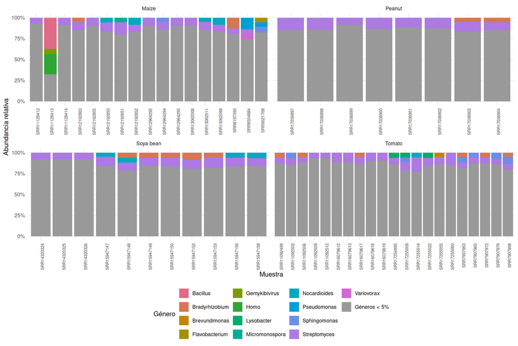

Figura 1: Composición por género, plantas con al menos cinco muestras.

```r
p_generos <- ggplot(graf_generos, aes(sample_id, abundancia_relativa, fill = taxon_final)) +
  geom_col() +
  facet_wrap(~ host_name, scales = "free_x", ncol = 2) +
  scale_fill_manual(values = colores_generos, breaks = orden_generos) +
  scale_y_continuous(labels = scales::label_percent()) +
  labs(x = "Muestra", y = "Abundancia relativa", fill = "Género") +
  theme_minimal() +
  theme(axis.text.x = element_text(angle = 90, hjust = 1, size = 7),
        legend.position = "bottom") +
  guides(fill = guide_legend(ncol = 4))
p_generos
ggsave("figures/generos_por_planta.png", p_generos, width = 12, height = 8, dpi = 150)
```

Las cuatro plantas seleccionadas reúnen 57 muestras. La categoría Géneros < 5% concentra gran parte de la composición en todas ellas. Streptomyces destaca en las cuatro, mientras Bradyrhizobium se distingue en cacahuate y soya. Las muestras de una misma planta no tienen exactamente la misma composición. El tamaño de muestra es desigual y las muestras pueden pertenecer a distintos estudios.

### 10.12.2 — Ejercicio 2: composición por filo según país

**Código**

```r
paises <- metadata_riz %>% count(country, name = "muestras") %>%
  filter(!is.na(country), muestras >= 5) %>% arrange(desc(muestras))
knitr::kable(paises)
```

| country | muestras |
| --- | --- |
| South Africa | 27 |
| China | 21 |
| Mexico | 10 |
| Netherlands | 7 |

**Código**

```r
graf_filos <- filos_5 %>%
  left_join(metadata_riz %>% select(sample_id, country), by = "sample_id") %>%
  filter(country %in% paises$country)
orden_filos <- c(sort(setdiff(unique(graf_filos$taxon_final), "Filos < 5%")),
                 "Filos < 5%")
graf_filos <- graf_filos %>%
  mutate(taxon_final = factor(taxon_final, levels = orden_filos))
colores_filos <- setNames(grDevices::hcl.colors(length(orden_filos), "Dark 3"), orden_filos)
colores_filos["Filos < 5%"] <- "#999999"
```

**Código**

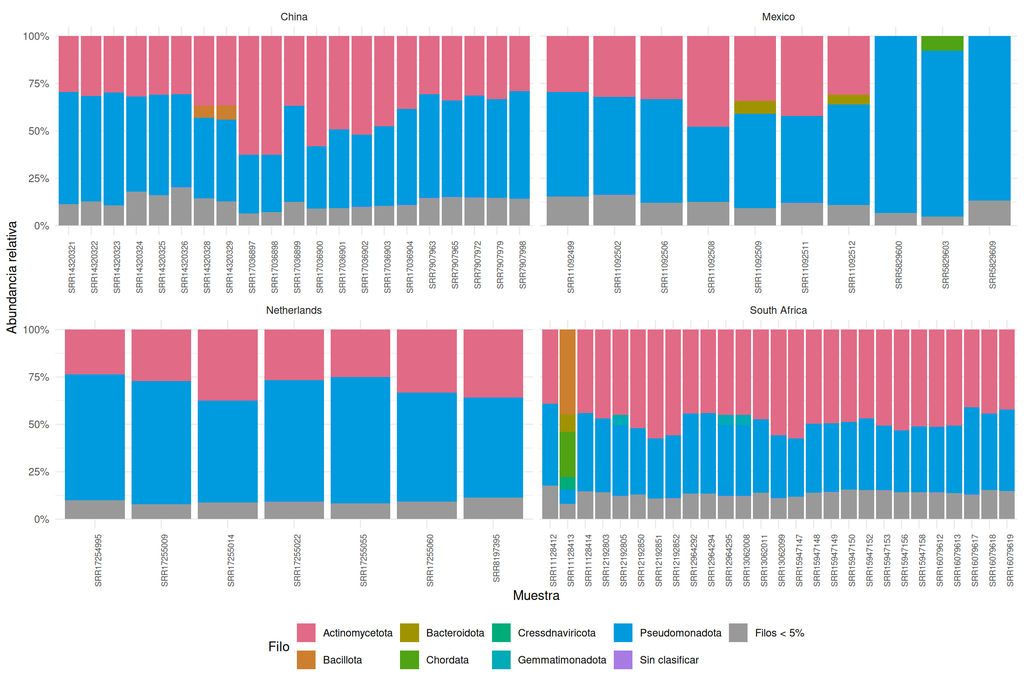

Figura 2: Composición por filo, países con al menos cinco muestras.

```r
p_filos <- ggplot(graf_filos, aes(sample_id, abundancia_relativa, fill = taxon_final)) +
  geom_col() +
  facet_wrap(~ country, scales = "free_x", ncol = 2) +
  scale_fill_manual(values = colores_filos, breaks = orden_filos) +
  scale_y_continuous(labels = scales::label_percent()) +
  labs(x = "Muestra", y = "Abundancia relativa", fill = "Filo") +
  theme_minimal() +
  theme(axis.text.x = element_text(angle = 90, hjust = 1, size = 7),
        legend.position = "bottom")
p_filos
ggsave("figures/filos_por_pais.png", p_filos, width = 12, height = 8, dpi = 150)
```

Los cuatro países seleccionados reúnen 65 muestras. Pseudomonadota destaca en México, Países Bajos y China, mientras Actinomycetota destaca en Sudáfrica al considerar las proporciones promedio. También se aprecia variabilidad entre muestras del mismo país. No podemos atribuir estas variaciones únicamente al país: la planta, el suelo y los protocolos también pueden influir.

# Discusión

Los ejercicios muestran cómo pasar de datos sin organizar a tablas y figuras que ayudan a explorar preguntas biológicas. La validación de identificadores, valores faltantes y totales es importante para evitar errores. Tanto la comparación de expresión génica como la composición por muestras son descriptivas; no permiten afirmar causalidad ni significancia estadística. Para investigar las diferencias con mayor detalle habría que considerar las réplicas, la normalización, la procedencia y los posibles efectos de estudio.

# Conclusiones

Aprendí a utilizar los objetos de R, condicionales, ciclos y funciones; importar y revisar datos, resumir grupos, integrar metadatos y generar gráficas con ggplot2. El reporte reúne el código, resultados y explicaciones necesarias para entender el procedimiento y volver a ejecutarlo.

# Reproducibilidad y fuentes

El documento se generará con Quarto mediante `quarto render reporte.qmd` desde la raíz del proyecto. La configuración sigue el [tema 11](https://cursosenesjuriquilla.github.io/Intro_to_R_Bioinfo_2027-1/parte11.html). Los ejercicios y conjuntos de datos provienen del [curso Introducción a R para Bioinformática I](https://cursosenesjuriquilla.github.io/Intro_to_R_Bioinfo_2027-1/index.html), de Haydeé Peruyero, ENES Juriquilla, UNAM.

**Código**